# Malformation Analysis

Author

Ryan Taylor

# Overview

This document consolidates our work on a Bayesian hierarchical model using a soap-film smoother to describe the patterns of volume abnormalities in children with craniosynostosis.

# Data

Data were sent by collaborators at Colorado (primarily Antonio Porras, Alejandro Cruz Guerrero, and Connor Elkhill).

Covariates are stored in a “merged_covariates” csv file that Josh Lukemire created from these data. Each image’s malformation map is stored as a $500 \times 500$ matrix in its own RData file saved in a data folder in Josh’s OneDrive.

We clean the covariate data set for easier analysis and to identify rare subsets of the data that should be excluded from our early work.

```r
# Set directory for references
here::i_am("2025.08_Malformation_Analysis.qmd")

# Set data folder
DATA_F <- here::here("../../data/Lukemire, Joshua's files - data/")

# Set subfolder with image data
MAP_F <- paste0(DATA_F, "unsigned_distances/")

# List all files with any extension (so no folders)
data_files <- list.files(MAP_F, pattern = "\\.")

# Read in covariates data
cranio_raw <- read_csv(paste0(DATA_F, "merged_covariates.csv"))

# Establish constanta

MAX_AGE <- 365
```

First, we ensure that all images in the covariate data are represented in the data folder and vice versa.

```r
### Clean cranio covariates file

## Create new data set with easier names
cranio <- cranio_raw %>%
  clean_names()

## Check if files in data were found in data folder
cranio %<>%
  mutate(
    fname = paste0(id_fmt, "_desc-unsigneddist.RData"),
    fname_exists = if_else(fname %in% data_files, 1, 0)
  )

# Print a table to check we have all files
fname_summ <- tibble(
  in_data_not_folder = sum(1 - cranio$fname_exists),
  in_folder_not_data = sum(!data_files %in% cranio$fname)
)

kbl(fname_summ, caption = "Check Files vs. Data Availability") %>%
  kable_styling(full_width = F)
```

Check Files vs. Data Availability

| in_data_not_folder | in_folder_not_data |
| --- | --- |
| 0 | 0 |

Next, we create a cleaner categorization of each image’s suture fusions. Information about the suture fusions for each image are initially stored in a series of binary columns: *metopic_fused, sagittal_fused, left_coronal_fused, right_coronal_fused, left_lambdoid_fused, right_lambdoid_fused*. We combine these into one column and create categories for “Bicoronal” and “Multiple.”

```r
#| label: clean sutures

## Classify sutures

# Currently stored in binary columns with names ending in "fused"
# Reshape data to identify all combinations of sutures
fusion_df <- cranio %>%
  select(id_fmt, matches("fused")) %>%
  pivot_longer(cols = -id_fmt) %>%
  mutate(
    name = name %>%
      str_remove("_fused") %>%
      str_replace_all("_", " ") %>%
      str_to_title()
  ) %>%
  mutate(fusion = if_else(value == 1, name, NA_character_)) %>%
  group_by(id_fmt) %>%
  summarize(num_fusions = sum(value, na.rm = T),
            fusions = paste(na.omit(fusion), collapse = "/")) %>%
  ungroup()

# (1) count number of sutures
# (2) identify bicoronal (the only useful instance of multiple sutures)
# (3) identify other instances of multiple sutures
# (3) assign remaining suture types
cranio %<>%
  left_join(fusion_df) %>%
  mutate(fusion_type = case_when(
    num_fusions == 0 ~ "None",
    fusions == "Left Coronal/Right Coronal" ~ "Bicoronal",
    num_fusions > 1 ~ "Multiple",
    T ~ fusions
  )) %>%
  mutate(fusion_type = fct_infreq(fusion_type))

# Summarize frequencies of each suture type
fusion_summ <- cranio %>%
  group_by(fusion_type) %>%
  summarize(pics = n(),
            patients = n_distinct(id_base)) %>%
  arrange(desc(pics)) %>%
  mutate(pics_pct = pics / sum(pics),
         patients_pct = patients / sum(patients)) %>%
  adorn_totals("row")

kbl(fusion_summ, caption = "Suture Fusions: Full Data") %>%
  kable_styling(full_width = F)
```

Suture Fusions: Full Data

| fusion_type | pics | patients | pics_pct | patients_pct |
| --- | --- | --- | --- | --- |
| None | 1718 | 1718 | 0.6542270 | 0.6972403 |
| Sagittal | 506 | 419 | 0.1926885 | 0.1700487 |
| Metopic | 155 | 118 | 0.0590251 | 0.0478896 |
| Multiple | 81 | 71 | 0.0308454 | 0.0288149 |
| Right Coronal | 65 | 53 | 0.0247525 | 0.0215097 |
| Bicoronal | 47 | 40 | 0.0178979 | 0.0162338 |
| Left Coronal | 37 | 36 | 0.0140899 | 0.0146104 |
| Left Lambdoid | 10 | 6 | 0.0038081 | 0.0024351 |
| Right Lambdoid | 7 | 3 | 0.0026657 | 0.0012175 |
| Total | 2626 | 2464 | 1.0000000 | 1.0000000 |

Next, we look at the availability of longitudinal data. No longitudinal data exist for patients with no suture fusions. Patients with suture fusions have an average of about 1.5 visits per person, and this average is fairly consistent even when we limit to the number of visits taken before the 1 year mark.

```r
# Identify which visit each image is from and how many visits they had
visits_summ <- cranio %>%
  arrange(id_base, age) %>%
  group_by(id_base) %>%
  mutate(visit_num = 1:n()) %>%
  # Count visits total and visits under age limit (currently 1 year)
  mutate(visits = max(visit_num),
         visits_max_age = max(visit_num[age <= MAX_AGE], na.rm = T)) %>%
  ungroup() %>%
  # Summarize visits on average and max by fusion group
  group_by(fusion_type) %>%
  summarize(patients = n_distinct(id_base),
            pics = n(),
            visits_avg = mean(visits),
            visits_max = max(visits),
            visits_avg_max_age = mean(if_else(is.infinite(visits_max_age),
                                              NA_real_,
                                              visits_max_age),
                                      na.rm = T),
            visits_max_max_age = max(visits_max_age, na.rm = T)) %>%
  arrange(desc(visits_avg))

kbl(visits_summ, caption = "Longitudinal Visits: Full Data") %>%
  kable_styling(full_width = F)
```

Longitudinal Visits: Full Data

| fusion_type | patients | pics | visits_avg | visits_max | visits_avg_max_age | visits_max_max_age |
| --- | --- | --- | --- | --- | --- | --- |
| Right Lambdoid | 3 | 7 | 2.714286 | 3 | 1.428571 | 2 |
| Left Lambdoid | 6 | 10 | 2.000000 | 3 | 1.285714 | 2 |
| Metopic | 118 | 155 | 1.593548 | 3 | 1.452555 | 3 |
| Right Coronal | 53 | 65 | 1.523077 | 4 | 1.561403 | 4 |
| Sagittal | 419 | 506 | 1.426878 | 5 | 1.354545 | 5 |
| Bicoronal | 40 | 47 | 1.425532 | 4 | 1.166667 | 2 |
| Multiple | 71 | 81 | 1.296296 | 3 | 1.339286 | 3 |
| Left Coronal | 36 | 37 | 1.054054 | 2 | 1.062500 | 2 |
| None | 1718 | 1718 | 1.000000 | 1 | 1.000000 | 1 |

Next, we consider exclusion criteria.

First, there are a small number of patients who were labeled by the collaborators as “Craniosynostosis,” but have no suture fusions. Close inspection reveals that these are 6 of the 7 patients in the data with “sphenoidal involvement.” Therefore, we exclude these 7 images.

Fifth, the median age in our data is 340 days, but the maximum is 3,695 days. We have found in previous work that brain growth is approximately linear over the first year, but slows down after that. To keep a consistent trend in our data, we exclude patients above 1 year of age.

```r
#| label: exclusion criteria

## Investigate any issues with fusion type
# Sanity check: fusion category against collaborators' "group" column
fusion_group_summ <- tabyl(cranio, fusion_type, group)

kbl(fusion_group_summ, caption = "Collaborators' Group vs. Fusions") %>%
  kable_styling(full_width = F)
```

Collaborators' Group vs. Fusions

| fusion_type | Craniosynostosis | Normative |
| --- | --- | --- |
| None | 6 | 1712 |
| Sagittal | 506 | 0 |
| Metopic | 155 | 0 |
| Multiple | 81 | 0 |
| Right Coronal | 65 | 0 |
| Bicoronal | 47 | 0 |
| Left Coronal | 37 | 0 |
| Left Lambdoid | 10 | 0 |
| Right Lambdoid | 7 | 0 |

```r
# Check the 6 images in "Craniosynostosis" group with no sutures
cranio_none <- cranio %>%
  filter(group == "Craniosynostosis" & fusion_type == "None")

# These children all have sphenoidal involvement
cranio_sphen <- cranio %>%
  group_by(fusion_type, group, sphenoidal_involvement) %>%
  summarize(n = n()) %>%
  ungroup() %>%
  arrange(desc(n))

kbl(cranio_sphen, caption = "Spehnoidal Involvement Summary") %>%
  kable_styling(full_width = F)
```

Spehnoidal Involvement Summary

| fusion_type | group | sphenoidal_involvement | n |
| --- | --- | --- | --- |
| None | Normative |  | 1712 |
| Sagittal | Craniosynostosis | 0 | 506 |
| Metopic | Craniosynostosis | 0 | 155 |
| Multiple | Craniosynostosis | 0 | 81 |
| Right Coronal | Craniosynostosis | 0 | 65 |
| Bicoronal | Craniosynostosis | 0 | 46 |
| Left Coronal | Craniosynostosis | 0 | 37 |
| Left Lambdoid | Craniosynostosis | 0 | 10 |
| Right Lambdoid | Craniosynostosis | 0 | 7 |
| None | Craniosynostosis | 1 | 6 |
| Bicoronal | Craniosynostosis | 1 | 1 |

```r
## Investigate multiple sutures

fusion_multiple_summ <- cranio %>%
  filter(fusion_type == "Multiple") %>%
  group_by(num_fusions, fusions) %>%
  summarize(pics = n(),
            patients = n_distinct(id_base)) %>%
  ungroup() %>%
  arrange(desc(pics))

kbl(fusion_multiple_summ, caption = "Summary of Multiple Fusions") %>%
  kable_styling(full_width = F)
```

Summary of Multiple Fusions

| num_fusions | fusions | pics | patients |
| --- | --- | --- | --- |
| 6 | Metopic/Sagittal/Left Coronal/Right Coronal/Left Lambdoid/Right Lambdoid | 14 | 14 |
| 3 | Sagittal/Left Coronal/Right Coronal | 12 | 11 |
| 2 | Metopic/Sagittal | 9 | 8 |
| 2 | Sagittal/Left Coronal | 7 | 4 |
| 3 | Sagittal/Left Lambdoid/Right Lambdoid | 7 | 5 |
| 4 | Metopic/Sagittal/Left Coronal/Right Coronal | 7 | 5 |
| 3 | Left Coronal/Right Coronal/Right Lambdoid | 4 | 4 |
| 2 | Sagittal/Right Coronal | 3 | 2 |
| 3 | Metopic/Left Coronal/Right Coronal | 3 | 3 |
| 5 | Metopic/Sagittal/Left Coronal/Right Coronal/Left Lambdoid | 3 | 3 |
| 2 | Sagittal/Right Lambdoid | 2 | 2 |
| 5 | Sagittal/Left Coronal/Right Coronal/Left Lambdoid/Right Lambdoid | 2 | 2 |
| 2 | Left Coronal/Left Lambdoid | 1 | 1 |
| 2 | Right Coronal/Right Lambdoid | 1 | 1 |
| 3 | Left Coronal/Right Coronal/Left Lambdoid | 1 | 1 |
| 3 | Metopic/Left Lambdoid/Right Lambdoid | 1 | 1 |
| 3 | Sagittal/Right Coronal/Left Lambdoid | 1 | 1 |
| 3 | Sagittal/Right Coronal/Right Lambdoid | 1 | 1 |
| 4 | Sagittal/Left Coronal/Left Lambdoid/Right Lambdoid | 1 | 1 |
| 4 | Sagittal/Right Coronal/Left Lambdoid/Right Lambdoid | 1 | 1 |

```r
max_multiple_count <- max(fusion_multiple_summ$pics)

## Investigate previous surgery
cranio_surg <- cranio %>%
  filter(previous_surgery == 1) %>%
  group_by(fusion_type, group, sphenoidal_involvement) %>%
  summarize(n = n()) %>%
  ungroup() %>%
  arrange(desc(n)) %>%
  adorn_totals("row")

kbl(cranio_surg, caption = "Images with Previous Surgery") %>%
  kable_styling(full_width = F)
```

Images with Previous Surgery

| fusion_type | group | sphenoidal_involvement | n |
| --- | --- | --- | --- |
| Sagittal | Craniosynostosis | 0 | 8 |
| Multiple | Craniosynostosis | 0 | 6 |
| Bicoronal | Craniosynostosis | 0 | 2 |
| Metopic | Craniosynostosis | 0 | 1 |
| Left Coronal | Craniosynostosis | 0 | 1 |
| Total | - | 0 | 18 |

```r
### Create subset data
# Exclude rare fusion categories: multiple, lambdoid
# Exclude sphenoidal involvement (in Craniosynostosis group without suture)
# Exclude patients with previous surgery (10)
# Limit to max 1 year old
cranio_sub <- cranio %>%
  filter(!fusion_type %in% c("Multiple",
                             "Left Lambdoid", "Right Lambdoid") &
           sphenoidal_involvement %in% c(NA, 0) &
           previous_surgery %in% c(NA, 0) &
           age <= MAX_AGE) %>%
  # Reduce number of columns
  select(id_base, fname, fusion_type,
         age, sex) %>%
  arrange(id_base, age)

# Create version of data with only last image
cranio_sub_last <- cranio_sub %>%
  group_by(id_base) %>%
  slice_tail(n = 1) %>%
  ungroup()
```

We generate a summary of the fusion types present in the remaining observations, to compare against the full data.

```r
fusion_summ_sub <- cranio_sub %>%
  group_by(fusion_type) %>%
  summarize(pics = n(),
            patients = n_distinct(id_base)) %>%
  arrange(desc(pics)) %>%
  mutate(pics_pct = pics / sum(pics),
         patients_pct = patients / sum(patients)) %>%
  adorn_totals("row")

kbl(fusion_summ_sub, caption = "Fusions in Subset Data") %>%
  kable_styling(full_width = F)
```

Fusions in Subset Data

| fusion_type | pics | patients | pics_pct | patients_pct |
| --- | --- | --- | --- | --- |
| None | 593 | 593 | 0.4640063 | 0.5055413 |
| Sagittal | 434 | 369 | 0.3395931 | 0.3145780 |
| Metopic | 130 | 105 | 0.1017214 | 0.0895141 |
| Right Coronal | 56 | 45 | 0.0438185 | 0.0383632 |
| Bicoronal | 34 | 31 | 0.0266041 | 0.0264280 |
| Left Coronal | 31 | 30 | 0.0242567 | 0.0255754 |
| Total | 1278 | 1173 | 1.0000000 | 1.0000000 |

Next, we load the malformation maps into one data set. Each malformation map is stored as a $500 \times 500$ matrix of pointwise absolute value differences, and is saved in its own RData file. We load each RData file in the remaining subset of images selected above, and convert each matrix into a `data.table` object. Then, we combine these all into one data.table and reshape this object from wide to long. The resulting data set contains 250,000 rows for each image with one column for the row index in the matrix, one column for the column index in the matrix, and one column containing the pointwise difference for that matrix cell.

```r
#|label: load maps

# Clear memory space

rm(list = setdiff(ls(), c("cranio_sub_last", "MAP_F"))); gc()
```

```
          used  (Mb) gc trigger  (Mb) limit (Mb) max used  (Mb)
Ncells 2794448 149.3    4925915 263.1         NA  4925915 263.1
Vcells 4946381  37.8   10146329  77.5      24576  7182731  54.8
```

```r
# Save row number for merging later
cranio_sub_last %<>% mutate(image_num = 1:n())

# Load in all malformation maps
map_ls <- map(1:nrow(cranio_sub_last),
              function(z){
                load(paste0(MAP_F, cranio_sub_last$fname[z]))

                # Convert to data.table for quick manipulation
                w <- data.table(pointwise_diff)[
                  # Add file name
                  , image_num := z]

                if(z %% 50 == 0){ cat("On row", z, "\n") }

                return(w)
              })
```

```
On row 50
On row 100
On row 150
On row 200
On row 250
On row 300
On row 350
On row 400
On row 450
On row 500
On row 550
On row 600
On row 650
On row 700
On row 750
On row 800
On row 850
On row 900
On row 950
On row 1000
On row 1050
On row 1100
On row 1150
```

```r
# Merge these into the same data table
map_dt <- rbindlist(map_ls)

rm(map_ls); gc()
```

```
            used   (Mb) gc trigger   (Mb) limit (Mb)  max used   (Mb)
Ncells   2830695  151.2    6330390  338.1         NA   6330390  338.1
Vcells 301586298 2301.0  622721105 4751.0      24576 596114879 4548.0
```

```r
# Add row number for each image
map_dt[, row := as.numeric(1:.N), by = image_num]

# Reshape to long
map_dt <- melt(map_dt, id.vars = c("row", "image_num"),
               variable.name = "col",
               value.name = "diff",
               variable.factor = FALSE)

# Clean column indicator
map_dt[, col := as.numeric(substr(col, start = 2, stop = 4))]

# Bring image number back in front
setcolorder(map_dt, c("image_num", "row", "col", "diff"))
```

For easier analysis of these malformation maps, we then merge covariates onto this malformation map data set. Since the image data is large, this is a memory-intensive merge. To address this, we first trim the maps data down to the smallest rectangle that includes every non-missing pointwise difference. Next, we select very few covariates to merge. We keep the demographics age, sex, patient ID, and suture fusion category, and retain an image identifier to match with the covariates data.

```r
# Identify extent of actual brain shape
map_range <- map_dt[, .(min_row = min(row[!is.na(diff)], na.rm = T),
                        max_row = max(row[!is.na(diff)], na.rm = T),
                        min_col = min(col[!is.na(diff)], na.rm = T),
                        max_col = max(col[!is.na(diff)], na.rm = T))]

# Filter data to this range of rows and columns
map_dt <- map_dt[
  row >= map_range$min_row &
    row <= map_range$max_row &
    col >= map_range$min_col &
    col <= map_range$max_col
]

### Merge covariates to malformation maps

# Convert covariates to data.table
cranio_sub_last <- data.table(cranio_sub_last)

rm(); gc()
```

```
            used   (Mb) gc trigger    (Mb) limit (Mb)   max used    (Mb)
Ncells   2829022  151.1    6330390   338.1         NA    6330390   338.1
Vcells 273070963 2083.4 1632269524 12453.3      24576 2035087948 15526.5
```

```r
# Left join cranio_sub_last onto map_dt;
# Create new columns in map_dt coming from cranio_sub_last ("i")
map_dt[cranio_sub_last,
       on = "image_num",
       `:=`(id_base = i.id_base,
            age = i.age,
            sex = i.sex,
            fusion_type = i.fusion_type)]
```

With this combined image and covariates data, we begin plotting malformation maps. First, we check whether all images have non-missing pointwise differences in the same matrix cells.

```r
# Identify range of values for plots
diff_range <- c("min" = min(map_dt$diff, na.rm = T),
                "max" = max(map_dt$diff, na.rm = T))

### Understand where missing values are located

# Count non-missing values by row and column
map_locs <- map_dt[, .(non_na = sum(!is.na(diff))), by = .(row, col)]

# Plot non-missing values
plot_map_locs <- ggplot(map_locs) +
  geom_raster(aes(x = row, y = col, fill = non_na)) +
  coord_fixed()

# Summarize non-missing values
kbl(tabyl(map_locs, non_na), caption = "Non-Missing Matrix Cells") %>%
  kable_styling(full_width = F)
```

Non-Missing Matrix Cells

| non_na | n | percent |
| --- | --- | --- |
| 0 | 12478 | 0.1911283 |
| 1173 | 52808 | 0.8088717 |

Next, we summarize the average differences by suture fusion and plot these averages on the brain shape.

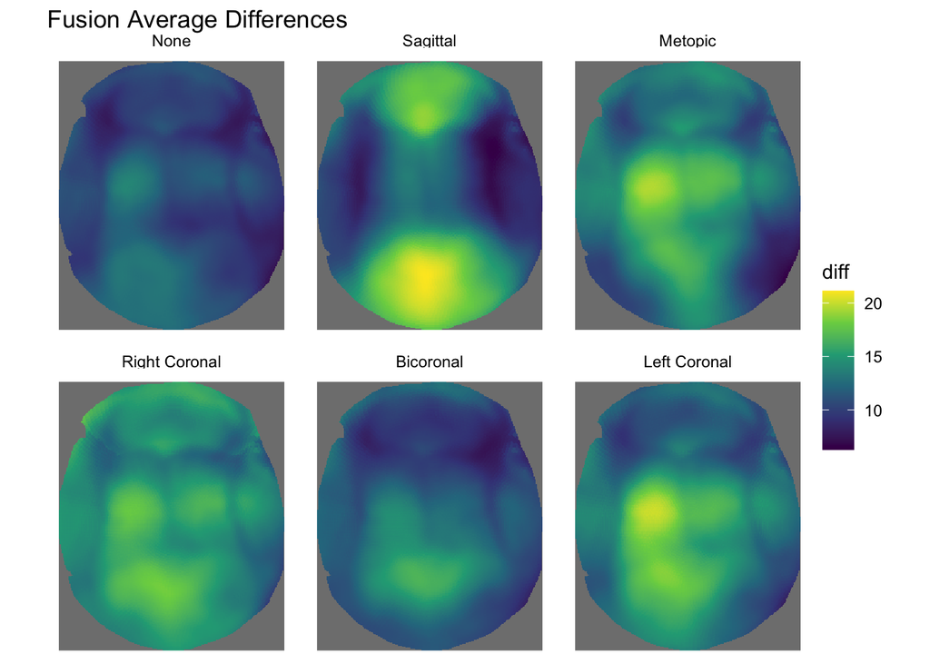

```r
#| label: map fusions

### Summarize differences by fusions

# Create dataset of average cell for each fusion
map_fusion <- map_dt[, .(diff = mean(diff)), by = .(fusion_type, row, col)]

# Plot brain map by fusion type
plot_fusion <- ggplot(map_fusion) +
  geom_raster(aes(x = row, y = col, fill = diff)) +
  facet_wrap(~fusion_type) +
  coord_fixed() +
  theme_void() +
  scale_fill_viridis_c() +
  labs(title = "Fusion Average Differences")

# Print fusion maps
plot_fusion
```

We add to this summary by showing how these averages change on average over time, dividing age into 6 bins of roughly 2-month windows of ages. We also compare these results to the sample sizes in each of these age-fusion bins.

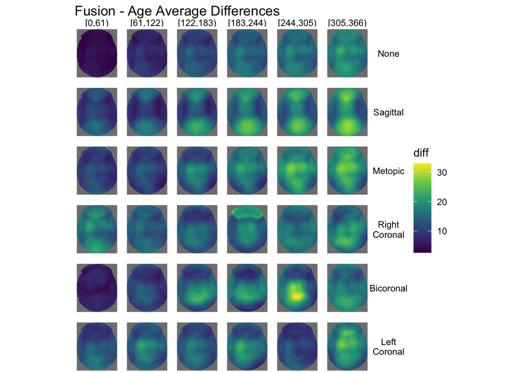

```r
### Investigate age

# Add 6 categories of age
map_dt[,
       age_bin := cut(age, breaks = seq(0, 366, 61), right = FALSE)]

# Take average pointwise differences in cell by fusion and age
map_fusion_age <- map_dt[, .(diff = mean(diff)),
                         by = .(fusion_type, age_bin, row, col)]

# Plot brain map by fusion type and age
plot_fusion_age <- ggplot(map_fusion_age) +
  geom_raster(aes(x = row, y = col, fill = diff)) +
  facet_grid(fusion_type ~ age_bin,
             labeller = label_wrap_gen(width = 10)) +
  coord_fixed() +
  scale_fill_viridis_c() +
  theme_void() +
  theme(axis.text = element_blank(),
        axis.ticks = element_blank()) +
  labs(title = "Fusion - Age Average Differences")

# Print fusion maps
plot_fusion_age
```

```r
# Determine sample size for these averages

# Count images per fusion and age bin
size_fusion_age <- map_dt[
  , .(n = uniqueN(image_num)),
  by = .(fusion_type, age_bin)
]

# Reshape to match plot
size_fusion_age <- dcast(size_fusion_age, fusion_type ~ age_bin,
                         value.var = "n")

# Print table
kbl(size_fusion_age, caption = "Fusion-Age Sample Size") %>%
  kable_styling(full_width = F)
```

Fusion-Age Sample Size

| fusion_type | [0,61) | [61,122) | [122,183) | [183,244) | [244,305) | [305,366) |
| --- | --- | --- | --- | --- | --- | --- |
| None | 131 | 134 | 104 | 70 | 72 | 82 |
| Sagittal | 66 | 136 | 90 | 36 | 23 | 18 |
| Metopic | 16 | 32 | 20 | 18 | 11 | 8 |
| Right Coronal | 5 | 16 | 9 | 6 | 6 | 3 |
| Bicoronal | 9 | 8 | 4 | 3 | 1 | 6 |
| Left Coronal | 5 | 7 | 8 | 6 | 2 | 2 |

Finally, we consider how each fusion type might differ between the two natal sexes recorded in the data.

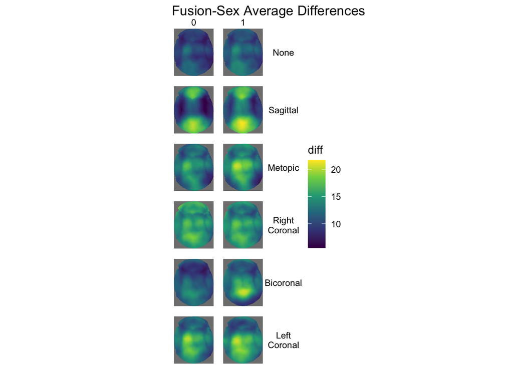

```r
# Take average pointwise differences in cell by fusion and sex
map_fusion_sex <- map_dt[, .(diff = mean(diff)),
                         by = .(fusion_type, sex, row, col)]

# Plot brain map by fusion type and age
plot_fusion_sex <- ggplot(map_fusion_sex) +
  geom_raster(aes(x = row, y = col, fill = diff)) +
  facet_grid(fusion_type ~ sex,
             labeller = label_wrap_gen(width = 9)) +
  coord_fixed() +
  scale_fill_viridis_c() +
  theme_void() +
  theme(axis.text = element_blank(),
        axis.ticks = element_blank()) +
  labs(title = "Fusion-Sex Average Differences")

# Print fusion maps
plot_fusion_sex
```

For a preliminary model, we filter to the most frequent combination of fusion type, age range, and sex with craniosynostosis. This includes all images with Sagittal fusion between the ages of 61-121 days with sex = 1. Our model does not reflect the brain boundary and does not incorporate these other demographics. It is a generalized additive model with an intercept and a tensor product smooth of row and column indices.

```r
rm(list = setdiff(ls(), c("cranio_sub_last", "map_dt", "map_range"))); gc()
```

```
            used   (Mb) gc trigger    (Mb) limit (Mb)   max used    (Mb)
Ncells   3012214  160.9    6330390   338.1         NA    6330390   338.1
Vcells 583268004 4450.0 1632269524 12453.3      24576 2035087948 15526.5
```

```r
# Count images by fusion, age, and sex
size_fusion_age_sex <- map_dt[
  , .(n = uniqueN(image_num)),
  by = .(fusion_type, age_bin, sex)
][, dcast(.SD, fusion_type + sex ~ age_bin, value.var = "n", fill = 0)]

# Print before deleting to save memory
kbl(size_fusion_age_sex, caption = "Fusion-Sex-Age Sample Size")
```

Fusion-Sex-Age Sample Size

| fusion_type | sex | [0,61) | [61,122) | [122,183) | [183,244) | [244,305) | [305,366) |
| --- | --- | --- | --- | --- | --- | --- | --- |
| None | 0 | 58 | 55 | 56 | 31 | 35 | 38 |
| None | 1 | 73 | 79 | 48 | 39 | 37 | 44 |
| Sagittal | 0 | 18 | 45 | 28 | 17 | 5 | 6 |
| Sagittal | 1 | 48 | 91 | 62 | 19 | 18 | 12 |
| Metopic | 0 | 6 | 10 | 5 | 7 | 1 | 5 |
| Metopic | 1 | 10 | 22 | 15 | 11 | 10 | 3 |
| Right Coronal | 0 | 3 | 9 | 3 | 4 | 5 | 2 |
| Right Coronal | 1 | 2 | 7 | 6 | 2 | 1 | 1 |
| Bicoronal | 0 | 6 | 6 | 2 | 2 | 0 | 4 |
| Bicoronal | 1 | 3 | 2 | 2 | 1 | 1 | 2 |
| Left Coronal | 0 | 3 | 6 | 6 | 5 | 2 | 2 |
| Left Coronal | 1 | 2 | 1 | 2 | 1 | 0 | 0 |

```r
rm(size_fusion_age_sex); gc()
```

```
            used   (Mb) gc trigger    (Mb) limit (Mb)   max used    (Mb)
Ncells   3012394  160.9    6330390   338.1         NA    6330390   338.1
Vcells 583310441 4450.4 1632269524 12453.3      24576 2035087948 15526.5
```

```r
# Run model on most common subset using coordinates
model_sagittal <- gam(diff ~ te(row, col),
                      data = map_dt[fusion_type == "Sagittal" &
                         age_bin == "[61,122)" &
                         sex == 1])

# Generate predictions from this model in a new dataset
new_dt <- get_predictions(model_sagittal,
                          cond = list("row" = seq(from = map_range$min_row,
                                                  to = map_range$max_row,
                                                  length.out = 50),
                                      "col" = seq(from = map_range$min_col,
                                                  to = map_range$max_col,
                                                  length.out = 50)))
```

```
Summary:
    * row : numeric predictor; with 50 values ranging from 131.000000 to 364.000000.
    * col : numeric predictor; with 50 values ranging from 121.000000 to 399.000000.
    * NOTE : No random effects in the model to cancel.
```

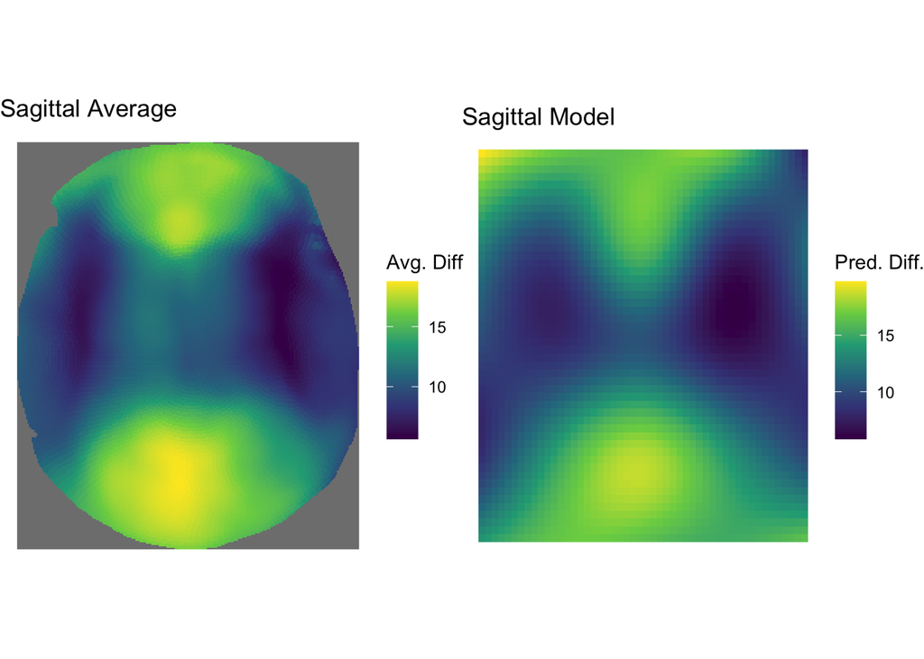

```r
# Plot these predictions (in a rectangle shape)
plot_model_sag <- ggplot(new_dt) +
  geom_raster(aes(x = row, y = col, fill = fit)) +
  coord_fixed() +
  scale_fill_viridis_c() +
  theme_void() +
  theme(axis.text = element_blank(),
        axis.ticks = element_blank()) +
  labs(title = "Sagittal Model",
       fill = "Pred. Diff.")

# Plot the averages in this dataset to compare
plot_actual_sag <- ggplot(map_dt[fusion_type == "Sagittal" &
                         age_bin == "[61,122)" &
                         sex == 1,
                         .(diff = mean(diff)),
                         by = .(row, col)]) +
  geom_raster(aes(x = row, y = col, fill = diff)) +
  coord_fixed() +
  scale_fill_viridis_c() +
  theme_void() +
  theme(axis.text = element_blank(),
        axis.ticks = element_blank()) +
  labs(title = "Sagittal Average",
       fill = "Avg. Diff")

# Arrange these two plots side by side
ggarrange(plot_actual_sag, plot_model_sag)
```